# Queer Coded: Supervised ML to Predict LGBTQ+ Acceptance in American Neighborhoods

Final Project Progress Memo 1– STAT 301-3 Data Science 3 with R

Author

Vlad Nevirkovets, Sean Pascoe, Dylan Yan

Published

April 30, 2023

**Github Repo Link**

https://github.com/STAT301-3-2023SP/final-project-central-limit-heros

## Prediction Project Outline

### Introduction

Neighborhoods with a high queer population, or [*Gayborhoods*](https://en.wikipedia.org/wiki/Gay_village), have been urban areas in which LGBTQ+ people have found community and built culture worldwide. However, these geographic areas serve as much more than the sexuality of their constituents, and have been cited as yielding robust creative economies, as well as a welcoming environment for those of many identities. Knowing this, the identity of a certain locale as a Gayborhood becomes a crucial sociological metric, with neighborhoods with a more prevalent queer identity driving social liberalism in the face of prejudice. Our analysis thus focuses on building a **location-based regression model** that uses a variety of parameters including housing, land use, and non-queer demographic data **to predict Gayborhood degree**, and, in so doing, determine whether an area is suitable for queer folks with the goal of advancing understanding of liberal areas.

### Outcome Variable

In order to rank Gayborhood status, we are using a published dataset [from data world](https://data.world/the-pudding/gayborhoods)[^1] that was analyzed to display distribution of queer communities in Jan Diehm’s 2018 article [*Men are from Chelsea, Women are from Park Slope*](https://pudding.cool/2018/06/gayborhoods/). Specifically, the metrics in this dataset are combined to form a Gayborhood index, which we will use as the supervising variable for our machine learning project. This index is a holistic assessment of queerness, derived primarily from the following measures:

- Same-sex joint tax filers
- Unmarried partner same sex households
- Number of Gay Bars
- Whether or not a pride parade routes through the region

In this case, we will be training a regression model to predict Gayborhood index. The initial variable exists on a 0 to 100 scale with a mean of 2.39, median of 1.27, and a max of 67.1. Because of this heavy right skew, we are choosing to model the log 10 transformation of the data, which is significantly more normal, and will thus fit better with our chosen models:

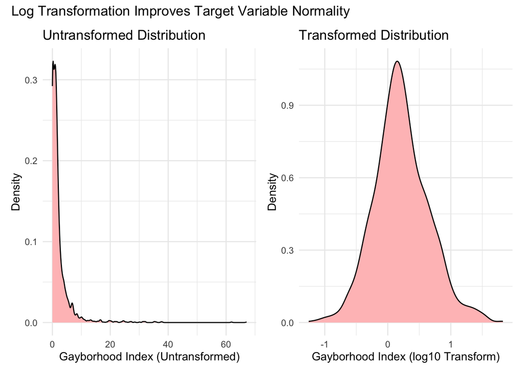

### Predictor Variables

Because this project is based primarily on data by ZCTA, a US Census-defined zipcode proxy, we are able to pool data from two main sources – the US Census and Open ICPSR– to encompass 4 major facets of urban life.

|  | variable |
| --- | --- |
| 1 | estimate_sex_and_age_total_population |
| 2 | estimate_sex_and_age_total_population_male |
| 3 | estimate_sex_and_age_total_population_female |
| 4 | estimate_sex_and_age_under_5_years |
| 5 | estimate_sex_and_age_5_to_9_years |
| 6 | estimate_sex_and_age_10_to_14_years |
| 7 | estimate_sex_and_age_15_to_19_years |
| 8 | estimate_sex_and_age_20_to_24_years |
| 9 | estimate_sex_and_age_25_to_34_years |
| 10 | estimate_sex_and_age_35_to_44_years |

[output cut: 570 more lines]

### Issues and Challenges

Collecting and cleaning the data was fairly easy. The census data is well organized, and generally has low missingness, which allowed us to only throw out a few potential predictors and will allow us to impute the rest. For cleaning of census data, we also removed columns that contained margins of error and annotations rather than the actual variables. The parks data required the removal of some text form within the data columns and conversion to numeric format. After cleaning individually, all datasets were then combined into a single dataset.

Because census predictors were numerous, any variables with greater than 10% missing were removed. The remaining missing values are summarized in the table below, with higher missingness listed first. The missingness in these variables are assumed to be randomly missing since they were collected and reported in the US Census ACS survey:

|  | variable | n_miss | pct_miss |
| --- | --- | --- | --- |
| 1 | estimate_value_owner_occupied_units_median_dollars | 152 | 6.5658747300216 |
| 2 | nonfamily_households_estimate_median_income_dollars | 139 | 6.00431965442765 |
| 3 | estimate_rooms_total_housing_units_median_rooms | 133 | 5.7451403887689 |
| 4 | car_truck_or_van_carpooled_estimate_workers_16_years_and_over_in_households_housing_tenure_owner_occupied_housing_units | 132 | 5.70194384449244 |
| 5 | car_truck_or_van_carpooled_estimate_workers_16_years_and_over_in_households_housing_tenure_renter_occupied_housing_units | 132 | 5.70194384449244 |
| 6 | car_truck_or_van_carpooled_estimate_vehicles_available_no_vehicle_available | 132 | 5.70194384449244 |
| 7 | car_truck_or_van_carpooled_estimate_vehicles_available_1_vehicle_available | 132 | 5.70194384449244 |
| 8 | car_truck_or_van_carpooled_estimate_vehicles_available_2_vehicles_available | 132 | 5.70194384449244 |
| 9 | car_truck_or_van_carpooled_estimate_vehicles_available_3_or_more_vehicles_available | 132 | 5.70194384449244 |
| 10 | car_truck_or_van_carpooled_estimate_poverty_status_in_the_past_12_months_workers_16_years_and_over_for_whom_poverty_status_is_determined_below_100_percent_of_the_poverty_level | 131 | 5.65874730021598 |

[output cut: 572 more lines]

## Initial Steps

### Resampling

To ensure robust resampling analysis, data was first *split 80/20* :: training/test to ensure enough observations were included in training data to avoid overfitting. Because our data is very wide in comparison with its length, we have chosen to perform *v-fold cross validation* with *8 folds* and *5 repeats*, in order to estimate chosen hyperparameters for our regression models.

### Feature Engineering Workflows

- For this analysis, we propose two main feature engineering pipelines to be applied across all model types.
1. *Lasso Parameter Selection*: Before training our models, we will use lasso regression to select only variables that are contributing in large part to our lasso fit. Two-way interaction terms will then be added for important parameters.
2. *Dimensionality Reduction*: Because we have a large number of predictors, we will also train a model using Principal Component Analysis to select the top principal components that are derived from these input parameters. This will also help to describe variance in the dataset without overfitting to many parameters.

*NOTE:* All models will have randomly missing variables imputed using linear imputation. Near zero variance predictors will also be removed before further analysis.

### Model Types

Because our goal is primarily predictive, we plan to train a variety of model types, focusing on those that are known to be successful with deep patterns in data, such as neural networks, which will be easier to train on our numerous predictors. We list the following as main model classes to investigate, and will move forward with classes that perform well across the first resamples:

- Penalized Elastic Net Regression
- Random Forest + Boosted Tree
- K-Nearest Neighbors
- Neural Networks
  - Basic neural networks using `nnet` in R
  - Using `keras` and [Tensorflow](https://www.tensorflow.org/) from python through R
- Multivariate Adaptive Regression Splines
- Cubist ensemble regression

Note that, because we have a large dataset with a regression analysis, we are generally avoiding the use of support vector machines.

### Comparison Metric

In order to select the best fitting models, we will choose primarily based on root mean squared error (RMSE). This is a sensible primary metric for our results as we have a specific numeric output that we are trying to predict, and thus will select models that are accurate. For resampled models that perform the same based on rmse, we will use Rsquared to choose models that are successfully modeling variance in the target variable.

## Footnotes

[^1]: Jan Diehm. (2018). *Gayborhoods* [Data set]. *The Pudding*, data.world. https://data.world/the-pudding/gayborhoods. Accessed 10 April 2023.
[^2]: US Census. (2021). *DP04: SELECTED HOUSING CHARACTERISTICS* [Data set]. data.census.gov. https://data.census.gov/table?q=rent&g=010XX00US$8600000&tid=ACSDP5Y2021.DP04. Accessed 24 April 2023.
[^3]: US Census. (2015). *DP05: ACS DEMOGRAPHIC AND HOUSING ESTIMATES* [Data set]. data.census.gov. https://data.census.gov/table?g=010XX00US$8600000&tid=ACSDP5Y2015.DP05. Accessed 26 April 2023.
[^4]: Li, Mao, Melendez, Robert, Khan, Anam, Gomez-Lopez, Iris, Clarke, Philippa, and Chenoweth, Megan. (2020). *National Neighborhood Data Archive (NaNDA): Parks by ZIP Code Tabulation Area, United States, 2018*. Ann Arbor, MI: Inter-university Consortium for Political and Social Research. https://doi.org/10.3886/E119803V1. Accessed 23 April 2023
[^5]: US Census. (2015). *S0802: MEANS OF TRANSPORTATION TO WORK BY SELECTED CHARACTERISTICS* [Data set]. data.census.gov. https://data.census.gov/table?q=commuting&g=010XX00US$8600000&tid=ACSST5Y2021.S0802. Accessed 30 April 2023.